# Risk Factor Analysis

## Outcome Variable

**Outcome Variable:** stunted

## Predictor Variables

**Intervention Variable:** parity

**Adjustment Set:**

- arm
- W_mage
- meducyrs
- feducyrs
- hhwealth_quart
- W_mhtcm
- vagbrth
- W_nrooms
- impsan
- delta_W_mage
- delta_meducyrs
- delta_feducyrs
- delta_hhwealth_quart
- delta_W_mhtcm
- delta_vagbrth
- delta_W_nrooms
- delta_impsan

## Stratifying Variables

The analysis was stratified on these variable(s):

- agecat
- studyid
- country

## Data Summary

| agecat | studyid | country | parity | stunted | n_cell | n |
| --- | --- | --- | --- | --- | --- | --- |
| Birth | ki1000304b-SAS-CompFeed | INDIA | 1 | 0 | 34 | 187 |
| Birth | ki1000304b-SAS-CompFeed | INDIA | 1 | 1 | 13 | 187 |
| Birth | ki1000304b-SAS-CompFeed | INDIA | 2 | 0 | 37 | 187 |
| Birth | ki1000304b-SAS-CompFeed | INDIA | 2 | 1 | 16 | 187 |
| Birth | ki1000304b-SAS-CompFeed | INDIA | 3+ | 0 | 70 | 187 |
| Birth | ki1000304b-SAS-CompFeed | INDIA | 3+ | 1 | 17 | 187 |
| Birth | ki1101329-Keneba | GAMBIA | 1 | 0 | 140 | 1407 |
| Birth | ki1101329-Keneba | GAMBIA | 1 | 1 | 16 | 1407 |
| Birth | ki1101329-Keneba | GAMBIA | 2 | 0 | 138 | 1407 |
| Birth | ki1101329-Keneba | GAMBIA | 2 | 1 | 8 | 1407 |
| Birth | ki1101329-Keneba | GAMBIA | 3+ | 0 | 1054 | 1407 |
| Birth | ki1101329-Keneba | GAMBIA | 3+ | 1 | 51 | 1407 |
| Birth | ki1126311-ZVITAMBO | ZIMBABWE | 1 | 0 | 5332 | 13829 |
| Birth | ki1126311-ZVITAMBO | ZIMBABWE | 1 | 1 | 640 | 13829 |
| Birth | ki1126311-ZVITAMBO | ZIMBABWE | 2 | 0 | 3718 | 13829 |
| Birth | ki1126311-ZVITAMBO | ZIMBABWE | 2 | 1 | 407 | 13829 |
| Birth | ki1126311-ZVITAMBO | ZIMBABWE | 3+ | 0 | 3347 | 13829 |
| Birth | ki1126311-ZVITAMBO | ZIMBABWE | 3+ | 1 | 385 | 13829 |
| Birth | ki1135781-COHORTS | GUATEMALA | 1 | 0 | 103 | 852 |
| Birth | ki1135781-COHORTS | GUATEMALA | 1 | 1 | 9 | 852 |
| Birth | ki1135781-COHORTS | GUATEMALA | 2 | 0 | 124 | 852 |
| Birth | ki1135781-COHORTS | GUATEMALA | 2 | 1 | 13 | 852 |
| Birth | ki1135781-COHORTS | GUATEMALA | 3+ | 0 | 575 | 852 |
| Birth | ki1135781-COHORTS | GUATEMALA | 3+ | 1 | 28 | 852 |
| Birth | ki1135781-COHORTS | INDIA | 1 | 0 | 582 | 4122 |
| Birth | ki1135781-COHORTS | INDIA | 1 | 1 | 114 | 4122 |
| Birth | ki1135781-COHORTS | INDIA | 2 | 0 | 939 | 4122 |
| Birth | ki1135781-COHORTS | INDIA | 2 | 1 | 98 | 4122 |
| Birth | ki1135781-COHORTS | INDIA | 3+ | 0 | 2126 | 4122 |
| Birth | ki1135781-COHORTS | INDIA | 3+ | 1 | 263 | 4122 |

[output cut: 132 more lines]

The following strata were considered:

- agecat: 24 months, studyid: ki1017093b-PROVIDE, country: BANGLADESH
- agecat: 24 months, studyid: ki1066203-TanzaniaChild2, country: TANZANIA, UNITED REPUBLIC OF
- agecat: 24 months, studyid: ki1101329-Keneba, country: GAMBIA
- agecat: 24 months, studyid: ki1113344-GMS-Nepal, country: NEPAL
- agecat: 24 months, studyid: ki1126311-ZVITAMBO, country: ZIMBABWE
- agecat: 24 months, studyid: ki1135781-COHORTS, country: GUATEMALA
- agecat: 24 months, studyid: ki1135781-COHORTS, country: INDIA
- agecat: 24 months, studyid: ki1135781-COHORTS, country: PHILIPPINES
- agecat: 24 months, studyid: kiGH5241-JiVitA-3, country: BANGLADESH
- agecat: 6 months, studyid: ki1000304b-SAS-CompFeed, country: INDIA
- agecat: 6 months, studyid: ki1000304b-SAS-FoodSuppl, country: INDIA
- agecat: 6 months, studyid: ki1017093b-PROVIDE, country: BANGLADESH
- agecat: 6 months, studyid: ki1066203-TanzaniaChild2, country: TANZANIA, UNITED REPUBLIC OF
- agecat: 6 months, studyid: ki1101329-Keneba, country: GAMBIA
- agecat: 6 months, studyid: ki1113344-GMS-Nepal, country: NEPAL
- agecat: 6 months, studyid: ki1126311-ZVITAMBO, country: ZIMBABWE
- agecat: 6 months, studyid: ki1135781-COHORTS, country: GUATEMALA
- agecat: 6 months, studyid: ki1135781-COHORTS, country: INDIA
- agecat: 6 months, studyid: ki1135781-COHORTS, country: PHILIPPINES
- agecat: 6 months, studyid: kiGH5241-JiVitA-3, country: BANGLADESH
- agecat: Birth, studyid: ki1000304b-SAS-CompFeed, country: INDIA
- agecat: Birth, studyid: ki1101329-Keneba, country: GAMBIA
- agecat: Birth, studyid: ki1126311-ZVITAMBO, country: ZIMBABWE
- agecat: Birth, studyid: ki1135781-COHORTS, country: GUATEMALA
- agecat: Birth, studyid: ki1135781-COHORTS, country: INDIA
- agecat: Birth, studyid: ki1135781-COHORTS, country: PHILIPPINES
- agecat: Birth, studyid: kiGH5241-JiVitA-3, country: BANGLADESH

### Dropped Strata

Some strata were dropped due to rare outcomes:

- agecat: 24 months, studyid: ki1066203-TanzaniaChild2, country: TANZANIA, UNITED REPUBLIC OF

## Methods Detail

We’re interested in the causal parameters $E[Y_a]$ for all values of $a \in \mathcal{A}$. These parameters represent the mean outcome if, possibly contrary to fact, we intervened to set all units to have $A=a$. Under the randomization and positivity assumptions, these are identified by the statistical parameters $\psi_a=E_W[E_{Y|A,W}(Y|A=a,W)]$. In addition, we’re interested in the mean of $Y$, $E[Y]$ under no intervention (the observed mean). We will estimate these parameters by using SuperLearner to fit the relevant likelihood factors – $E_{Y|A,W}(Y|A=a,W)$ and $p(A=a|W)$, and then updating our likelihood fit using a joint TMLE.

For unadjusted analyses ($W=\{\}$), initial likelihoods were estimated using Lrnr_glm to estimate the simple $E(Y|A)$ and Lrnr_mean to estimate $p(A)$. For adjusted analyses, a small library containing Lrnr_glmnet, Lrnr_xgboost, and Lrnr_mean was used.

Having estimated these parameters, we will then use the delta method to estimate relative risks and attributable risks relative to a prespecified baseline level of $A$.

# Results Detail

## Results Plots

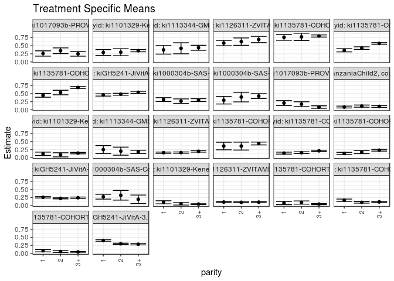

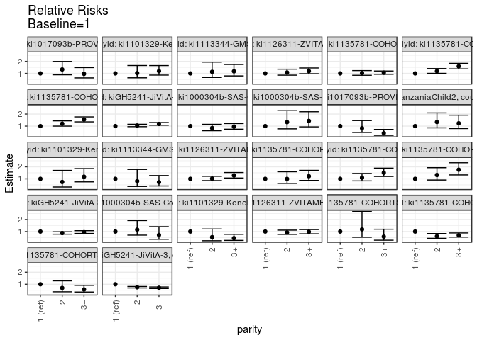

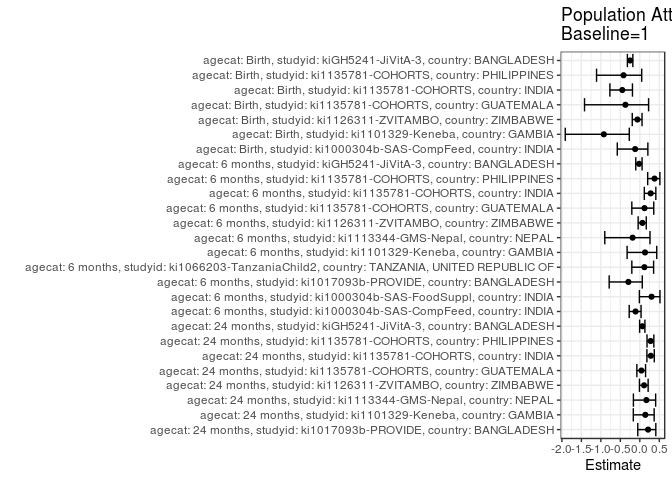

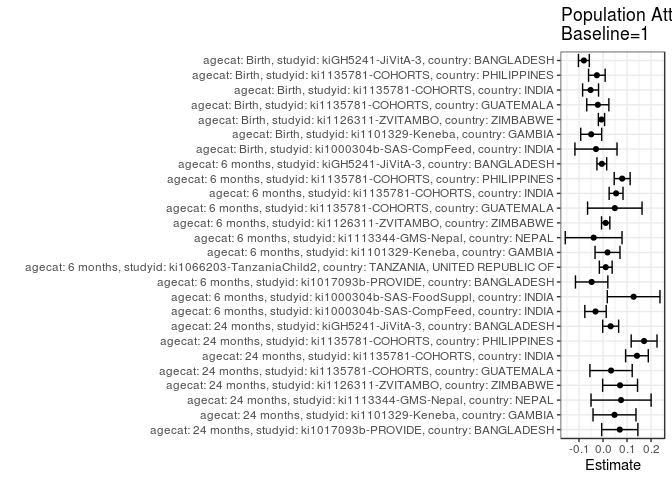

## Results Table

### Parameter: TSM

| agecat | studyid | country | intervention_level | baseline_level | estimate | ci_lower | ci_upper |
| --- | --- | --- | --- | --- | --- | --- | --- |
| Birth | ki1000304b-SAS-CompFeed | INDIA | 1 | NA | 0.2753371 | 0.2010563 | 0.3496179 |
| Birth | ki1000304b-SAS-CompFeed | INDIA | 2 | NA | 0.3186234 | 0.1694742 | 0.4677726 |
| Birth | ki1000304b-SAS-CompFeed | INDIA | 3+ | NA | 0.1956179 | 0.0647369 | 0.3264990 |
| Birth | ki1101329-Keneba | GAMBIA | 1 | NA | 0.1025641 | 0.0549386 | 0.1501896 |
| Birth | ki1101329-Keneba | GAMBIA | 2 | NA | 0.0547945 | 0.0178664 | 0.0917227 |
| Birth | ki1101329-Keneba | GAMBIA | 3+ | NA | 0.0461538 | 0.0337783 | 0.0585294 |
| Birth | ki1126311-ZVITAMBO | ZIMBABWE | 1 | NA | 0.1099041 | 0.0959512 | 0.1238570 |
| Birth | ki1126311-ZVITAMBO | ZIMBABWE | 2 | NA | 0.1015510 | 0.0875222 | 0.1155798 |
| Birth | ki1126311-ZVITAMBO | ZIMBABWE | 3+ | NA | 0.1068450 | 0.0930086 | 0.1206813 |
| Birth | ki1135781-COHORTS | GUATEMALA | 1 | NA | 0.0803571 | 0.0299820 | 0.1307322 |
| Birth | ki1135781-COHORTS | GUATEMALA | 2 | NA | 0.0948905 | 0.0457879 | 0.1439931 |
| Birth | ki1135781-COHORTS | GUATEMALA | 3+ | NA | 0.0464345 | 0.0296294 | 0.0632396 |
| Birth | ki1135781-COHORTS | INDIA | 1 | NA | 0.1670922 | 0.1317173 | 0.2024671 |
| Birth | ki1135781-COHORTS | INDIA | 2 | NA | 0.1010641 | 0.0766054 | 0.1255227 |
| Birth | ki1135781-COHORTS | INDIA | 3+ | NA | 0.1150137 | 0.1004445 | 0.1295828 |
| Birth | ki1135781-COHORTS | PHILIPPINES | 1 | NA | 0.0869061 | 0.0508979 | 0.1229143 |
| Birth | ki1135781-COHORTS | PHILIPPINES | 2 | NA | 0.0603379 | 0.0329616 | 0.0877143 |
| Birth | ki1135781-COHORTS | PHILIPPINES | 3+ | NA | 0.0495778 | 0.0385446 | 0.0606111 |
| Birth | kiGH5241-JiVitA-3 | BANGLADESH | 1 | NA | 0.4030528 | 0.3788944 | 0.4272112 |
| Birth | kiGH5241-JiVitA-3 | BANGLADESH | 2 | NA | 0.3020916 | 0.2846260 | 0.3195572 |
| Birth | kiGH5241-JiVitA-3 | BANGLADESH | 3+ | NA | 0.2864968 | 0.2668026 | 0.3061911 |
| 6 months | ki1000304b-SAS-CompFeed | INDIA | 1 | NA | 0.3156762 | 0.2567219 | 0.3746306 |
| 6 months | ki1000304b-SAS-CompFeed | INDIA | 2 | NA | 0.2651645 | 0.1935443 | 0.3367847 |
| 6 months | ki1000304b-SAS-CompFeed | INDIA | 3+ | NA | 0.2997611 | 0.2558996 | 0.3436225 |
| 6 months | ki1000304b-SAS-FoodSuppl | INDIA | 1 | NA | 0.2960349 | 0.1798624 | 0.4122075 |
| 6 months | ki1000304b-SAS-FoodSuppl | INDIA | 2 | NA | 0.3934943 | 0.2446172 | 0.5423713 |
| 6 months | ki1000304b-SAS-FoodSuppl | INDIA | 3+ | NA | 0.4242481 | 0.3502738 | 0.4982223 |
| 6 months | ki1017093b-PROVIDE | BANGLADESH | 1 | NA | 0.2086235 | 0.1326791 | 0.2845679 |
| 6 months | ki1017093b-PROVIDE | BANGLADESH | 2 | NA | 0.1734062 | 0.0983096 | 0.2485028 |
| 6 months | ki1017093b-PROVIDE | BANGLADESH | 3+ | NA | 0.0851798 | 0.0470377 | 0.1233220 |
| 6 months | ki1066203-TanzaniaChild2 | TANZANIA, UNITED REPUBLIC OF | 1 | NA | 0.0853616 | 0.0562598 | 0.1144635 |
| 6 months | ki1066203-TanzaniaChild2 | TANZANIA, UNITED REPUBLIC OF | 2 | NA | 0.1143693 | 0.0812251 | 0.1475136 |
| 6 months | ki1066203-TanzaniaChild2 | TANZANIA, UNITED REPUBLIC OF | 3+ | NA | 0.1052336 | 0.0765437 | 0.1339236 |
| 6 months | ki1101329-Keneba | GAMBIA | 1 | NA | 0.1211273 | 0.0696143 | 0.1726403 |
| 6 months | ki1101329-Keneba | GAMBIA | 2 | NA | 0.0892949 | 0.0251078 | 0.1534821 |
| 6 months | ki1101329-Keneba | GAMBIA | 3+ | NA | 0.1423260 | 0.1197567 | 0.1648953 |
| 6 months | ki1113344-GMS-Nepal | NEPAL | 1 | NA | 0.2504097 | 0.1264617 | 0.3743578 |
| 6 months | ki1113344-GMS-Nepal | NEPAL | 2 | NA | 0.2024559 | 0.0783330 | 0.3265789 |
| 6 months | ki1113344-GMS-Nepal | NEPAL | 3+ | NA | 0.1800584 | 0.1292054 | 0.2309113 |
| 6 months | ki1126311-ZVITAMBO | ZIMBABWE | 1 | NA | 0.1550905 | 0.1362301 | 0.1739509 |
| 6 months | ki1126311-ZVITAMBO | ZIMBABWE | 2 | NA | 0.1574767 | 0.1375501 | 0.1774033 |
| 6 months | ki1126311-ZVITAMBO | ZIMBABWE | 3+ | NA | 0.1980024 | 0.1723526 | 0.2236522 |
| 6 months | ki1135781-COHORTS | GUATEMALA | 1 | NA | 0.3608787 | 0.2443037 | 0.4774537 |
| 6 months | ki1135781-COHORTS | GUATEMALA | 2 | NA | 0.3586336 | 0.2360410 | 0.4812261 |
| 6 months | ki1135781-COHORTS | GUATEMALA | 3+ | NA | 0.4393207 | 0.3954330 | 0.4832084 |
| 6 months | ki1135781-COHORTS | INDIA | 1 | NA | 0.1413062 | 0.1112714 | 0.1713409 |
| 6 months | ki1135781-COHORTS | INDIA | 2 | NA | 0.1547254 | 0.1270502 | 0.1824007 |
| 6 months | ki1135781-COHORTS | INDIA | 3+ | NA | 0.2124761 | 0.1945714 | 0.2303807 |
| 6 months | ki1135781-COHORTS | PHILIPPINES | 1 | NA | 0.1314392 | 0.0972267 | 0.1656517 |
| 6 months | ki1135781-COHORTS | PHILIPPINES | 2 | NA | 0.1732043 | 0.1250334 | 0.2213753 |
| 6 months | ki1135781-COHORTS | PHILIPPINES | 3+ | NA | 0.2312442 | 0.2048620 | 0.2576263 |
| 6 months | kiGH5241-JiVitA-3 | BANGLADESH | 1 | NA | 0.2563995 | 0.2346607 | 0.2781384 |
| 6 months | kiGH5241-JiVitA-3 | BANGLADESH | 2 | NA | 0.2238710 | 0.2073853 | 0.2403568 |
| 6 months | kiGH5241-JiVitA-3 | BANGLADESH | 3+ | NA | 0.2433388 | 0.2214117 | 0.2652660 |
| 24 months | ki1017093b-PROVIDE | BANGLADESH | 1 | NA | 0.2594258 | 0.1774572 | 0.3413944 |
| 24 months | ki1017093b-PROVIDE | BANGLADESH | 2 | NA | 0.3441155 | 0.2562303 | 0.4320007 |
| 24 months | ki1017093b-PROVIDE | BANGLADESH | 3+ | NA | 0.2500242 | 0.1773007 | 0.3227477 |
| 24 months | ki1101329-Keneba | GAMBIA | 1 | NA | 0.2907799 | 0.2006267 | 0.3809330 |
| 24 months | ki1101329-Keneba | GAMBIA | 2 | NA | 0.2978256 | 0.1890730 | 0.4065781 |
| 24 months | ki1101329-Keneba | GAMBIA | 3+ | NA | 0.3467471 | 0.3124586 | 0.3810355 |
| 24 months | ki1113344-GMS-Nepal | NEPAL | 1 | NA | 0.3717001 | 0.2407451 | 0.5026551 |
| 24 months | ki1113344-GMS-Nepal | NEPAL | 2 | NA | 0.4207128 | 0.2503376 | 0.5910879 |
| 24 months | ki1113344-GMS-Nepal | NEPAL | 3+ | NA | 0.4362354 | 0.3592059 | 0.5132648 |
| 24 months | ki1126311-ZVITAMBO | ZIMBABWE | 1 | NA | 0.5823506 | 0.4988517 | 0.6658496 |
| 24 months | ki1126311-ZVITAMBO | ZIMBABWE | 2 | NA | 0.6260644 | 0.5116100 | 0.7405188 |
| 24 months | ki1126311-ZVITAMBO | ZIMBABWE | 3+ | NA | 0.6920416 | 0.5947304 | 0.7893528 |
| 24 months | ki1135781-COHORTS | GUATEMALA | 1 | NA | 0.7584643 | 0.6671254 | 0.8498031 |
| 24 months | ki1135781-COHORTS | GUATEMALA | 2 | NA | 0.7734515 | 0.6598383 | 0.8870647 |
| 24 months | ki1135781-COHORTS | GUATEMALA | 3+ | NA | 0.8004219 | 0.7674037 | 0.8334401 |
| 24 months | ki1135781-COHORTS | INDIA | 1 | NA | 0.3587379 | 0.3093268 | 0.4081490 |
| 24 months | ki1135781-COHORTS | INDIA | 2 | NA | 0.4260776 | 0.3856629 | 0.4664923 |
| 24 months | ki1135781-COHORTS | INDIA | 3+ | NA | 0.5703880 | 0.5462664 | 0.5945096 |
| 24 months | ki1135781-COHORTS | PHILIPPINES | 1 | NA | 0.4455838 | 0.3887414 | 0.5024262 |
| 24 months | ki1135781-COHORTS | PHILIPPINES | 2 | NA | 0.5341486 | 0.4645316 | 0.6037656 |
| 24 months | ki1135781-COHORTS | PHILIPPINES | 3+ | NA | 0.6887523 | 0.6603800 | 0.7171245 |
| 24 months | kiGH5241-JiVitA-3 | BANGLADESH | 1 | NA | 0.4589632 | 0.4241174 | 0.4938091 |
| 24 months | kiGH5241-JiVitA-3 | BANGLADESH | 2 | NA | 0.4810462 | 0.4506349 | 0.5114575 |
| 24 months | kiGH5241-JiVitA-3 | BANGLADESH | 3+ | NA | 0.5405612 | 0.5090765 | 0.5720459 |

### Parameter: E(Y)

| agecat | studyid | country | intervention_level | baseline_level | estimate | ci_lower | ci_upper |
| --- | --- | --- | --- | --- | --- | --- | --- |
| Birth | ki1000304b-SAS-CompFeed | INDIA | NA | NA | 0.2459893 | 0.1594019 | 0.3325767 |
| Birth | ki1101329-Keneba | GAMBIA | NA | NA | 0.0533049 | 0.0415629 | 0.0650470 |
| Birth | ki1126311-ZVITAMBO | ZIMBABWE | NA | NA | 0.1035505 | 0.0984723 | 0.1086287 |
| Birth | ki1135781-COHORTS | GUATEMALA | NA | NA | 0.0586854 | 0.0428942 | 0.0744767 |
| Birth | ki1135781-COHORTS | INDIA | NA | NA | 0.1152353 | 0.1054865 | 0.1249842 |
| Birth | ki1135781-COHORTS | PHILIPPINES | NA | NA | 0.0613115 | 0.0527962 | 0.0698268 |
| Birth | kiGH5241-JiVitA-3 | BANGLADESH | NA | NA | 0.3232622 | 0.3156056 | 0.3309189 |
| 6 months | ki1000304b-SAS-CompFeed | INDIA | NA | NA | 0.2844311 | 0.2666491 | 0.3022132 |
| 6 months | ki1000304b-SAS-FoodSuppl | INDIA | NA | NA | 0.4235925 | 0.3733796 | 0.4738054 |
| 6 months | ki1017093b-PROVIDE | BANGLADESH | NA | NA | 0.1612350 | 0.1313580 | 0.1911120 |
| 6 months | ki1066203-TanzaniaChild2 | TANZANIA, UNITED REPUBLIC OF | NA | NA | 0.0967419 | 0.0837671 | 0.1097166 |
| 6 months | ki1101329-Keneba | GAMBIA | NA | NA | 0.1398644 | 0.1229849 | 0.1567440 |
| 6 months | ki1113344-GMS-Nepal | NEPAL | NA | NA | 0.2113677 | 0.1776128 | 0.2451225 |
| 6 months | ki1126311-ZVITAMBO | ZIMBABWE | NA | NA | 0.1662648 | 0.1582516 | 0.1742780 |
| 6 months | ki1135781-COHORTS | GUATEMALA | NA | NA | 0.4099896 | 0.3788775 | 0.4411017 |
| 6 months | ki1135781-COHORTS | INDIA | NA | NA | 0.1957586 | 0.1838852 | 0.2076319 |
| 6 months | ki1135781-COHORTS | PHILIPPINES | NA | NA | 0.2112260 | 0.1958496 | 0.2266024 |
| 6 months | kiGH5241-JiVitA-3 | BANGLADESH | NA | NA | 0.2513837 | 0.2432545 | 0.2595129 |
| 24 months | ki1017093b-PROVIDE | BANGLADESH | NA | NA | 0.3292894 | 0.2909105 | 0.3676684 |
| 24 months | ki1101329-Keneba | GAMBIA | NA | NA | 0.3386628 | 0.3136483 | 0.3636773 |
| 24 months | ki1113344-GMS-Nepal | NEPAL | NA | NA | 0.4468938 | 0.4032281 | 0.4905594 |
| 24 months | ki1126311-ZVITAMBO | ZIMBABWE | NA | NA | 0.6535088 | 0.6097853 | 0.6972322 |
| 24 months | ki1135781-COHORTS | GUATEMALA | NA | NA | 0.7919400 | 0.7675726 | 0.8163075 |
| 24 months | ki1135781-COHORTS | INDIA | NA | NA | 0.5001478 | 0.4832966 | 0.5169990 |
| 24 months | ki1135781-COHORTS | PHILIPPINES | NA | NA | 0.6167689 | 0.5974942 | 0.6360437 |
| 24 months | kiGH5241-JiVitA-3 | BANGLADESH | NA | NA | 0.4908395 | 0.4777071 | 0.5039719 |

### Parameter: RR

| agecat | studyid | country | intervention_level | baseline_level | estimate | ci_lower | ci_upper |
| --- | --- | --- | --- | --- | --- | --- | --- |
| Birth | ki1000304b-SAS-CompFeed | INDIA | 1 | 1 | 1.0000000 | 1.0000000 | 1.0000000 |
| Birth | ki1000304b-SAS-CompFeed | INDIA | 2 | 1 | 1.1572120 | 0.7007696 | 1.9109554 |
| Birth | ki1000304b-SAS-CompFeed | INDIA | 3+ | 1 | 0.7104669 | 0.3591843 | 1.4053044 |
| Birth | ki1101329-Keneba | GAMBIA | 1 | 1 | 1.0000000 | 1.0000000 | 1.0000000 |
| Birth | ki1101329-Keneba | GAMBIA | 2 | 1 | 0.5342466 | 0.2356709 | 1.2110933 |
| Birth | ki1101329-Keneba | GAMBIA | 3+ | 1 | 0.4500000 | 0.2632335 | 0.7692791 |
| Birth | ki1126311-ZVITAMBO | ZIMBABWE | 1 | 1 | 1.0000000 | 1.0000000 | 1.0000000 |
| Birth | ki1126311-ZVITAMBO | ZIMBABWE | 2 | 1 | 0.9239964 | 0.7659500 | 1.1146541 |
| Birth | ki1126311-ZVITAMBO | ZIMBABWE | 3+ | 1 | 0.9721653 | 0.8109413 | 1.1654424 |
| Birth | ki1135781-COHORTS | GUATEMALA | 1 | 1 | 1.0000000 | 1.0000000 | 1.0000000 |
| Birth | ki1135781-COHORTS | GUATEMALA | 2 | 1 | 1.1808597 | 0.5238079 | 2.6621012 |
| Birth | ki1135781-COHORTS | GUATEMALA | 3+ | 1 | 0.5778515 | 0.2801877 | 1.1917454 |
| Birth | ki1135781-COHORTS | INDIA | 1 | 1 | 1.0000000 | 1.0000000 | 1.0000000 |
| Birth | ki1135781-COHORTS | INDIA | 2 | 1 | 0.6048401 | 0.4386936 | 0.8339113 |
| Birth | ki1135781-COHORTS | INDIA | 3+ | 1 | 0.6883245 | 0.5379269 | 0.8807714 |
| Birth | ki1135781-COHORTS | PHILIPPINES | 1 | 1 | 1.0000000 | 1.0000000 | 1.0000000 |
| Birth | ki1135781-COHORTS | PHILIPPINES | 2 | 1 | 0.6942888 | 0.3757572 | 1.2828415 |
| Birth | ki1135781-COHORTS | PHILIPPINES | 3+ | 1 | 0.5704761 | 0.3566259 | 0.9125613 |
| Birth | kiGH5241-JiVitA-3 | BANGLADESH | 1 | 1 | 1.0000000 | 1.0000000 | 1.0000000 |
| Birth | kiGH5241-JiVitA-3 | BANGLADESH | 2 | 1 | 0.7495088 | 0.6901591 | 0.8139622 |
| Birth | kiGH5241-JiVitA-3 | BANGLADESH | 3+ | 1 | 0.7108171 | 0.6498772 | 0.7774715 |
| 6 months | ki1000304b-SAS-CompFeed | INDIA | 1 | 1 | 1.0000000 | 1.0000000 | 1.0000000 |
| 6 months | ki1000304b-SAS-CompFeed | INDIA | 2 | 1 | 0.8399889 | 0.6151692 | 1.1469710 |
| 6 months | ki1000304b-SAS-CompFeed | INDIA | 3+ | 1 | 0.9495839 | 0.7429351 | 1.2137126 |
| 6 months | ki1000304b-SAS-FoodSuppl | INDIA | 1 | 1 | 1.0000000 | 1.0000000 | 1.0000000 |
| 6 months | ki1000304b-SAS-FoodSuppl | INDIA | 2 | 1 | 1.3292155 | 0.7737308 | 2.2834997 |
| 6 months | ki1000304b-SAS-FoodSuppl | INDIA | 3+ | 1 | 1.4331013 | 0.9359708 | 2.1942770 |
| 6 months | ki1017093b-PROVIDE | BANGLADESH | 1 | 1 | 1.0000000 | 1.0000000 | 1.0000000 |
| 6 months | ki1017093b-PROVIDE | BANGLADESH | 2 | 1 | 0.8311920 | 0.4728487 | 1.4611017 |
| 6 months | ki1017093b-PROVIDE | BANGLADESH | 3+ | 1 | 0.4082944 | 0.2295985 | 0.7260688 |
| 6 months | ki1066203-TanzaniaChild2 | TANZANIA, UNITED REPUBLIC OF | 1 | 1 | 1.0000000 | 1.0000000 | 1.0000000 |
| 6 months | ki1066203-TanzaniaChild2 | TANZANIA, UNITED REPUBLIC OF | 2 | 1 | 1.3398217 | 0.8568536 | 2.0950164 |
| 6 months | ki1066203-TanzaniaChild2 | TANZANIA, UNITED REPUBLIC OF | 3+ | 1 | 1.2327980 | 0.7967830 | 1.9074089 |
| 6 months | ki1101329-Keneba | GAMBIA | 1 | 1 | 1.0000000 | 1.0000000 | 1.0000000 |
| 6 months | ki1101329-Keneba | GAMBIA | 2 | 1 | 0.7371992 | 0.3197595 | 1.6995981 |
| 6 months | ki1101329-Keneba | GAMBIA | 3+ | 1 | 1.1750118 | 0.7463962 | 1.8497584 |
| 6 months | ki1113344-GMS-Nepal | NEPAL | 1 | 1 | 1.0000000 | 1.0000000 | 1.0000000 |
| 6 months | ki1113344-GMS-Nepal | NEPAL | 2 | 1 | 0.8084987 | 0.3673800 | 1.7792750 |
| 6 months | ki1113344-GMS-Nepal | NEPAL | 3+ | 1 | 0.7190549 | 0.4067283 | 1.2712173 |
| 6 months | ki1126311-ZVITAMBO | ZIMBABWE | 1 | 1 | 1.0000000 | 1.0000000 | 1.0000000 |
| 6 months | ki1126311-ZVITAMBO | ZIMBABWE | 2 | 1 | 1.0153861 | 0.8520993 | 1.2099633 |
| 6 months | ki1126311-ZVITAMBO | ZIMBABWE | 3+ | 1 | 1.2766897 | 1.0690564 | 1.5246496 |
| 6 months | ki1135781-COHORTS | GUATEMALA | 1 | 1 | 1.0000000 | 1.0000000 | 1.0000000 |
| 6 months | ki1135781-COHORTS | GUATEMALA | 2 | 1 | 0.9937787 | 0.6219074 | 1.5880113 |
| 6 months | ki1135781-COHORTS | GUATEMALA | 3+ | 1 | 1.2173639 | 0.8690160 | 1.7053482 |
| 6 months | ki1135781-COHORTS | INDIA | 1 | 1 | 1.0000000 | 1.0000000 | 1.0000000 |
| 6 months | ki1135781-COHORTS | INDIA | 2 | 1 | 1.0949659 | 0.8297877 | 1.4448881 |
| 6 months | ki1135781-COHORTS | INDIA | 3+ | 1 | 1.5036573 | 1.1968812 | 1.8890642 |
| 6 months | ki1135781-COHORTS | PHILIPPINES | 1 | 1 | 1.0000000 | 1.0000000 | 1.0000000 |
| 6 months | ki1135781-COHORTS | PHILIPPINES | 2 | 1 | 1.3177524 | 0.9014364 | 1.9263383 |
| 6 months | ki1135781-COHORTS | PHILIPPINES | 3+ | 1 | 1.7593240 | 1.3248089 | 2.3363529 |
| 6 months | kiGH5241-JiVitA-3 | BANGLADESH | 1 | 1 | 1.0000000 | 1.0000000 | 1.0000000 |
| 6 months | kiGH5241-JiVitA-3 | BANGLADESH | 2 | 1 | 0.8731336 | 0.7787740 | 0.9789262 |
| 6 months | kiGH5241-JiVitA-3 | BANGLADESH | 3+ | 1 | 0.9490611 | 0.8427151 | 1.0688274 |
| 24 months | ki1017093b-PROVIDE | BANGLADESH | 1 | 1 | 1.0000000 | 1.0000000 | 1.0000000 |
| 24 months | ki1017093b-PROVIDE | BANGLADESH | 2 | 1 | 1.3264504 | 0.8847189 | 1.9887342 |
| 24 months | ki1017093b-PROVIDE | BANGLADESH | 3+ | 1 | 0.9637597 | 0.6271916 | 1.4809394 |
| 24 months | ki1101329-Keneba | GAMBIA | 1 | 1 | 1.0000000 | 1.0000000 | 1.0000000 |
| 24 months | ki1101329-Keneba | GAMBIA | 2 | 1 | 1.0242304 | 0.6345980 | 1.6530906 |
| 24 months | ki1101329-Keneba | GAMBIA | 3+ | 1 | 1.1924728 | 0.8615886 | 1.6504296 |
| 24 months | ki1113344-GMS-Nepal | NEPAL | 1 | 1 | 1.0000000 | 1.0000000 | 1.0000000 |
| 24 months | ki1113344-GMS-Nepal | NEPAL | 2 | 1 | 1.1318608 | 0.6630499 | 1.9321456 |
| 24 months | ki1113344-GMS-Nepal | NEPAL | 3+ | 1 | 1.1736218 | 0.7920002 | 1.7391261 |
| 24 months | ki1126311-ZVITAMBO | ZIMBABWE | 1 | 1 | 1.0000000 | 1.0000000 | 1.0000000 |
| 24 months | ki1126311-ZVITAMBO | ZIMBABWE | 2 | 1 | 1.0750643 | 0.8545678 | 1.3524536 |
| 24 months | ki1126311-ZVITAMBO | ZIMBABWE | 3+ | 1 | 1.1883590 | 0.9738185 | 1.4501646 |
| 24 months | ki1135781-COHORTS | GUATEMALA | 1 | 1 | 1.0000000 | 1.0000000 | 1.0000000 |
| 24 months | ki1135781-COHORTS | GUATEMALA | 2 | 1 | 1.0197600 | 0.8434511 | 1.2329232 |
| 24 months | ki1135781-COHORTS | GUATEMALA | 3+ | 1 | 1.0553192 | 0.9295859 | 1.1980588 |
| 24 months | ki1135781-COHORTS | INDIA | 1 | 1 | 1.0000000 | 1.0000000 | 1.0000000 |
| 24 months | ki1135781-COHORTS | INDIA | 2 | 1 | 1.1877127 | 1.0058184 | 1.4025011 |
| 24 months | ki1135781-COHORTS | INDIA | 3+ | 1 | 1.5899852 | 1.3774333 | 1.8353360 |
| 24 months | ki1135781-COHORTS | PHILIPPINES | 1 | 1 | 1.0000000 | 1.0000000 | 1.0000000 |
| 24 months | ki1135781-COHORTS | PHILIPPINES | 2 | 1 | 1.1987613 | 1.0001658 | 1.4367904 |
| 24 months | ki1135781-COHORTS | PHILIPPINES | 3+ | 1 | 1.5457302 | 1.3527944 | 1.7661825 |
| 24 months | kiGH5241-JiVitA-3 | BANGLADESH | 1 | 1 | 1.0000000 | 1.0000000 | 1.0000000 |
| 24 months | kiGH5241-JiVitA-3 | BANGLADESH | 2 | 1 | 1.0481149 | 0.9522281 | 1.1536572 |
| 24 months | kiGH5241-JiVitA-3 | BANGLADESH | 3+ | 1 | 1.1777876 | 1.0723885 | 1.2935459 |

### Parameter: PAR

| agecat | studyid | country | intervention_level | baseline_level | estimate | ci_lower | ci_upper |
| --- | --- | --- | --- | --- | --- | --- | --- |
| Birth | ki1000304b-SAS-CompFeed | INDIA | 1 | NA | -0.0293478 | -0.1170494 | 0.0583538 |
| Birth | ki1101329-Keneba | GAMBIA | 1 | NA | -0.0492592 | -0.0928837 | -0.0056347 |
| Birth | ki1126311-ZVITAMBO | ZIMBABWE | 1 | NA | -0.0063536 | -0.0193058 | 0.0065986 |
| Birth | ki1135781-COHORTS | GUATEMALA | 1 | NA | -0.0216717 | -0.0677134 | 0.0243700 |
| Birth | ki1135781-COHORTS | INDIA | 1 | NA | -0.0518569 | -0.0850788 | -0.0186349 |
| Birth | ki1135781-COHORTS | PHILIPPINES | 1 | NA | -0.0255946 | -0.0601773 | 0.0089881 |
| Birth | kiGH5241-JiVitA-3 | BANGLADESH | 1 | NA | -0.0797906 | -0.1024393 | -0.0571419 |
| 6 months | ki1000304b-SAS-CompFeed | INDIA | 1 | NA | -0.0312451 | -0.0758264 | 0.0133362 |
| 6 months | ki1000304b-SAS-FoodSuppl | INDIA | 1 | NA | 0.1275575 | 0.0178132 | 0.2373019 |
| 6 months | ki1017093b-PROVIDE | BANGLADESH | 1 | NA | -0.0473885 | -0.1148510 | 0.0200740 |
| 6 months | ki1066203-TanzaniaChild2 | TANZANIA, UNITED REPUBLIC OF | 1 | NA | 0.0113802 | -0.0152525 | 0.0380130 |
| 6 months | ki1101329-Keneba | GAMBIA | 1 | NA | 0.0187372 | -0.0332523 | 0.0707266 |
| 6 months | ki1113344-GMS-Nepal | NEPAL | 1 | NA | -0.0390421 | -0.1572962 | 0.0792121 |
| 6 months | ki1126311-ZVITAMBO | ZIMBABWE | 1 | NA | 0.0111743 | -0.0061482 | 0.0284968 |
| 6 months | ki1135781-COHORTS | GUATEMALA | 1 | NA | 0.0491109 | -0.0643721 | 0.1625939 |
| 6 months | ki1135781-COHORTS | INDIA | 1 | NA | 0.0544524 | 0.0255494 | 0.0833554 |
| 6 months | ki1135781-COHORTS | PHILIPPINES | 1 | NA | 0.0797868 | 0.0465820 | 0.1129916 |
| 6 months | kiGH5241-JiVitA-3 | BANGLADESH | 1 | NA | -0.0050159 | -0.0253550 | 0.0153233 |
| 24 months | ki1017093b-PROVIDE | BANGLADESH | 1 | NA | 0.0698636 | -0.0055447 | 0.1452719 |
| 24 months | ki1101329-Keneba | GAMBIA | 1 | NA | 0.0478829 | -0.0416223 | 0.1373882 |
| 24 months | ki1113344-GMS-Nepal | NEPAL | 1 | NA | 0.0751937 | -0.0499777 | 0.2003651 |
| 24 months | ki1126311-ZVITAMBO | ZIMBABWE | 1 | NA | 0.0711581 | -0.0015029 | 0.1438192 |
| 24 months | ki1135781-COHORTS | GUATEMALA | 1 | NA | 0.0334758 | -0.0546725 | 0.1216241 |
| 24 months | ki1135781-COHORTS | INDIA | 1 | NA | 0.1414099 | 0.0941458 | 0.1886739 |
| 24 months | ki1135781-COHORTS | PHILIPPINES | 1 | NA | 0.1711851 | 0.1173678 | 0.2250025 |
| 24 months | kiGH5241-JiVitA-3 | BANGLADESH | 1 | NA | 0.0318763 | -0.0013138 | 0.0650664 |

### Parameter: PAF

| agecat | studyid | country | intervention_level | baseline_level | estimate | ci_lower | ci_upper |
| --- | --- | --- | --- | --- | --- | --- | --- |
| Birth | ki1000304b-SAS-CompFeed | INDIA | 1 | NA | -0.1193053 | -0.5782931 | 0.2062030 |
| Birth | ki1101329-Keneba | GAMBIA | 1 | NA | -0.9241025 | -1.9135260 | -0.2706839 |
| Birth | ki1126311-ZVITAMBO | ZIMBABWE | 1 | NA | -0.0613574 | -0.1941188 | 0.0566437 |
| Birth | ki1135781-COHORTS | GUATEMALA | 1 | NA | -0.3692857 | -1.4191803 | 0.2249675 |
| Birth | ki1135781-COHORTS | INDIA | 1 | NA | -0.4500085 | -0.7682546 | -0.1890396 |
| Birth | ki1135781-COHORTS | PHILIPPINES | 1 | NA | -0.4174522 | -1.1105367 | 0.0480285 |
| Birth | kiGH5241-JiVitA-3 | BANGLADESH | 1 | NA | -0.2468293 | -0.3189415 | -0.1786597 |
| 6 months | ki1000304b-SAS-CompFeed | INDIA | 1 | NA | -0.1098512 | -0.2724453 | 0.0319665 |
| 6 months | ki1000304b-SAS-FoodSuppl | INDIA | 1 | NA | 0.3011327 | -0.0110415 | 0.5169184 |
| 6 months | ki1017093b-PROVIDE | BANGLADESH | 1 | NA | -0.2939097 | -0.7867466 | 0.0629884 |
| 6 months | ki1066203-TanzaniaChild2 | TANZANIA, UNITED REPUBLIC OF | 1 | NA | 0.1176351 | -0.2051055 | 0.3539423 |
| 6 months | ki1101329-Keneba | GAMBIA | 1 | NA | 0.1339666 | -0.3260713 | 0.4344091 |
| 6 months | ki1113344-GMS-Nepal | NEPAL | 1 | NA | -0.1847116 | -0.8996145 | 0.2611439 |
| 6 months | ki1126311-ZVITAMBO | ZIMBABWE | 1 | NA | 0.0672078 | -0.0429642 | 0.1657419 |
| 6 months | ki1135781-COHORTS | GUATEMALA | 1 | NA | 0.1197857 | -0.2052261 | 0.3571520 |
| 6 months | ki1135781-COHORTS | INDIA | 1 | NA | 0.2781609 | 0.1153903 | 0.4109813 |
| 6 months | ki1135781-COHORTS | PHILIPPINES | 1 | NA | 0.3777319 | 0.2016514 | 0.5149768 |
| 6 months | kiGH5241-JiVitA-3 | BANGLADESH | 1 | NA | -0.0199530 | -0.1041756 | 0.0578454 |
| 24 months | ki1017093b-PROVIDE | BANGLADESH | 1 | NA | 0.2121647 | -0.0528626 | 0.4104791 |
| 24 months | ki1101329-Keneba | GAMBIA | 1 | NA | 0.1413882 | -0.1667561 | 0.3681506 |
| 24 months | ki1113344-GMS-Nepal | NEPAL | 1 | NA | 0.1682585 | -0.1645456 | 0.4059538 |
| 24 months | ki1126311-ZVITAMBO | ZIMBABWE | 1 | NA | 0.1088863 | -0.0095195 | 0.2134043 |
| 24 months | ki1135781-COHORTS | GUATEMALA | 1 | NA | 0.0422706 | -0.0757636 | 0.1473539 |
| 24 months | ki1135781-COHORTS | INDIA | 1 | NA | 0.2827361 | 0.1817015 | 0.3712961 |
| 24 months | ki1135781-COHORTS | PHILIPPINES | 1 | NA | 0.2775515 | 0.1844939 | 0.3599903 |
| 24 months | kiGH5241-JiVitA-3 | BANGLADESH | 1 | NA | 0.0649423 | -0.0050775 | 0.1300841 |